# Nienadzorowana Detekcja Fraudów Bankowych

# 13 Model 5: K-Means jako Detektor Anomalii

Odleglosc euklidesowa od centrum najblizszego klastra sluzy jako score anomalii. `k=3` jest motywowane wynikami segmentacji fraudow (Sekcja 21), ktora identyfikuje trzy strukturalnie rozne profile sprawcow.

```r
kmeans_path <- "saved_models/kmeans_k3.rds"
if (file.exists(kmeans_path)) {
  km <- readRDS(kmeans_path)
} else {
  set.seed(123)
  km <- kmeans(df_train_baked %>% select(-fraud_bool),
               centers=3, nstart=25, algorithm="Lloyd")
  saveRDS(km, kmeans_path)
}

test_mat     <- as.matrix(df_test_baked %>% select(-fraud_bool))
score_kmeans <- apply(test_mat, 1, function(row)
  min(sqrt(rowSums(sweep(km$centers, 2, row)^2))))

roc_kmeans <- roc(y_test, score_kmeans, quiet=TRUE)
cat("K-Means k=3 (OOS) - AUC:", round(auc(roc_kmeans),4), "\n")
```

```
## K-Means k=3 (OOS) - AUC: 0.5429
```

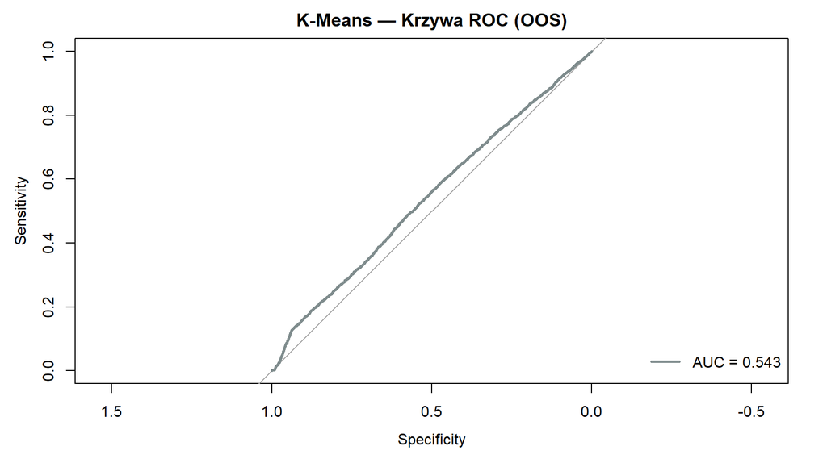

```r
plot(roc_kmeans, col="#7f8c8d", lwd=2.5, main="K-Means — Krzywa ROC (OOS)")
legend("bottomright", legend=paste("AUC =",round(auc(roc_kmeans),3)),
       col="#7f8c8d", lwd=2.5, bty="n")
```

```r
rm(test_mat); gc(verbose=FALSE)
```

```
##             used   (Mb) gc trigger   (Mb)  max used   (Mb)
## Ncells   3774236  201.6   10666598  569.7  10666598  569.7
## Vcells 245507282 1873.1  667184043 5090.3 666983351 5088.7
```

# 14 Model 6: One-Class SVM (OCSVM)

OCSVM (Scholkopf et al., 2001) uczy sie maksymalnego marginesu hipersfery otaczajacej rdzen legalnych transakcji w jaderowej przestrzeni cech. Transakcje poza granica dostaja wysoki score anomalii. Kernel RBF implicite obsluguje nieliniowosci bez jawnych zalozen dystrybucyjnych. `nu=0.011` jest ustawiony dokladnie na empiryczna czestotliwosc fraudow.

```r
ocsvm_path <- "saved_models/model_ocsvm.rds"
if (file.exists(ocsvm_path)) {
  model_ocsvm <- readRDS(ocsvm_path)
} else {
  set.seed(123)
  n_ocsvm <- min(50000, sum(df_train_baked$fraud_bool=="Legit"))
  legit_ocsvm <- df_train_baked %>%
    filter(fraud_bool=="Legit") %>% select(-fraud_bool) %>% slice_sample(n=n_ocsvm)
  model_ocsvm <- svm(x=legit_ocsvm, y=NULL, type="one-classification",
                     kernel="radial", nu=0.011,
                     gamma=1/ncol(legit_ocsvm), scale=FALSE)
  saveRDS(model_ocsvm, ocsvm_path)
}

score_ocsvm <- -as.numeric(attr(
  predict(model_ocsvm, newdata=df_test_baked %>% select(-fraud_bool),
          decision.values=TRUE), "decision.values"))

roc_ocsvm <- roc(y_test, score_ocsvm, quiet=TRUE)
cat("OCSVM (nu=0.011, 50k ref, OOS) - AUC:", round(auc(roc_ocsvm),4), "\n")
```

```
## OCSVM (nu=0.011, 50k ref, OOS) - AUC: 0.5828
```

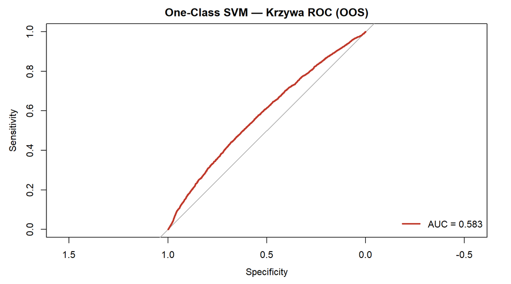

```r
plot(roc_ocsvm, col="#c0392b", lwd=2.5, main="One-Class SVM — Krzywa ROC (OOS)")
legend("bottomright", legend=paste("AUC =",round(auc(roc_ocsvm),3)),
       col="#c0392b", lwd=2.5, bty="n")
```

```r
gc(verbose=FALSE)
```

```
##             used   (Mb) gc trigger   (Mb)  max used   (Mb)
## Ncells   3776110  201.7   10666598  569.7  10666598  569.7
## Vcells 246634759 1881.7  667184043 5090.3 666983351 5088.7
```